# Time Series Feature: Time Series at Zurich Airport

This notebook demonstrates efficient geolocation and time-series access using Polytope feature extraction. By retrieving only the requested grid points, the I/O is greatly reduced and workflows can be considerably sped up.

[figure not shown]

## Installation

Follow the instructions in [README.md](https://github.com/MeteoSwiss/nwp-fdb-polytope-demo/blob/main/README.md#Installation-1) to install the necessary dependencies.

## Configuring Access to Polytope

To access ICON data via MeteoSwiss's Polytope, you need a Polytope offline token provided by MeteoSwiss. If you do not already have a token, you can request one [here](https://meteoswiss.atlassian.net/wiki/spaces/IW2/pages/327780397/Polytope#Offline-token-authentication). Then, create a new `config.yml` file based on `config_example.yml`, and replace <meteoswiss_key> with your access token there.

```python
import os
import yaml

def load_config(path="config.yml"):
    if not os.path.exists(path):
        raise FileNotFoundError("Missing config.yml. Please create one based on config_example.yml.")
    with open(path, "r") as f:
        return yaml.safe_load(f)

config = load_config()

# ICON-CSCS Polytope credentials
os.environ["POLYTOPE_USER_KEY"] = config["meteoswiss"]["key"]
os.environ["POLYTOPE_ADDRESS"] = "https://service.meteoswiss.ch/polytope"

# To clear the environment variable
os.environ["POLYTOPE_USER_EMAIL"] = ""
```

## Select the geolocation

We’ll request a time series at **Zurich Airport** (WGS84 coordinates).

```python
zrh_geo_point = (8.565074, 47.453928)  # (longitude, latitude) in WGS84
```

## Select the run date and time

The FDB containing real-time data typically **holds only the most recent day of forecasts**. The next cell computes a valid run time automatically.

```python
from datetime import datetime, timedelta

now = datetime.now()
past_time = now - timedelta(hours=12)                # use a recent past cycle
rounded_hour = (past_time.hour // 6) * 6             # round down to 6-hour cycles
rounded_time = past_time.replace(hour=rounded_hour, minute=0, second=0, microsecond=0)

date = rounded_time.strftime('%Y%m%d')
time = rounded_time.strftime('%H%M')
date, time
```

```
('20260805', '1800')
```

## Define the feature

Request a **time series at one point** (`zrh_geo_point`) over **steps 0–120**. ICON-CH2-EPS is hourly in this range (use 0–33 for ICON-CH1-EPS).

> **NOTE:** If points are `(longitude, latitude)`, set `axes=["longitude", "latitude"]`.

```python
feature = {
    "type": "timeseries",
    "points": [zrh_geo_point],      # single point (lon, lat)
    "time_axis": "step",
    "range": {"start": 0, "end": 120},   # hourly steps 0..120
    "axes": ["longitude", "latitude"]    # order must match the point tuple
}
```

## Define the request

This example fetches **2-m temperature** from **ICON-CH2-EPS** at the **surface**, for **ensemble member 1** (`number=1`), at the selected run date/time.

- `type="pf"` — perturbed member (requires `number`).
- `type="cf"` — control forecast (no `number`).

```python
request = {
    'param': '500011',
    'date': date,
    'time': time,
    'expver': '0001',
    'number': 1,
    'class': 'od',
    'levtype': 'sfc',
    'model': 'icon-ch2-eps',
    'stream': 'enfo',
    'type': 'pf',
    'feature': feature,
    'timespan': 'none'
}
```

## Data retrieval

Load the data with [earthkit.data](https://earthkit-data.readthedocs.io/en/latest/) and convert it to an [xarray.Dataset](https://docs.xarray.dev/en/stable/generated/xarray.Dataset.html).

```python
import earthkit.data as ekd
ds = ekd.from_source(
    "polytope",
    "mchgj",
    request,
    stream=False
).to_xarray()
```

```
2026-08-06 11:18:18 - INFO - Sending request...
{'request': 'class: od\n'
            "date: '20260805'\n"
            "expver: '0001'\n"
            'feature:\n'
            '  axes:\n'
            '  - longitude\n'
            '  - latitude\n'
            '  points:\n'
            '  - - 8.565074\n'
            '    - 47.453928\n'
            '  range:\n'
            '    end: 120\n'
            '    start: 0\n'
            '  time_axis: step\n'
            '  type: timeseries\n'
            'levtype: sfc\n'
            'model: icon-ch2-eps\n'
            'number: 1\n'
            "param: '500011'\n"
            'stream: enfo\n'
            "time: '1800'\n"
            'timespan: none\n'
            'type: pf\n',
 'verb': 'retrieve'}
2026-08-06 11:18:18 - INFO - Request accepted. Please poll ./b598230e-359e-4e30-93d1-f2a8937492f0 for status
2026-08-06 11:18:18 - INFO - Checking request status (b598230e-359e-4e30-93d1-f2a8937492f0)...
2026-08-06 11:18:18 - INFO - The current status of the request is 'queued'
2026-08-06 11:18:19 - INFO - The current status of the request is 'processing'
2026-08-06 11:18:21 - INFO - The current status of the request is 'processed'
```

## Plot the results

```python
from earthkit.plots.interactive import Chart


da = ds["t_2m"] - 273.15
da.attrs['units'] = "°C"

chart = Chart()
chart.line(da.to_dataset())
```

If you're viewing this on GitHub, plots are static and we export them as PNGs using `chart.show("png")`.

If you're running the notebook locally, use `chart.show()` to enable interactivity. You can hover over the chart to see precise timestamps and temperature values (°C).

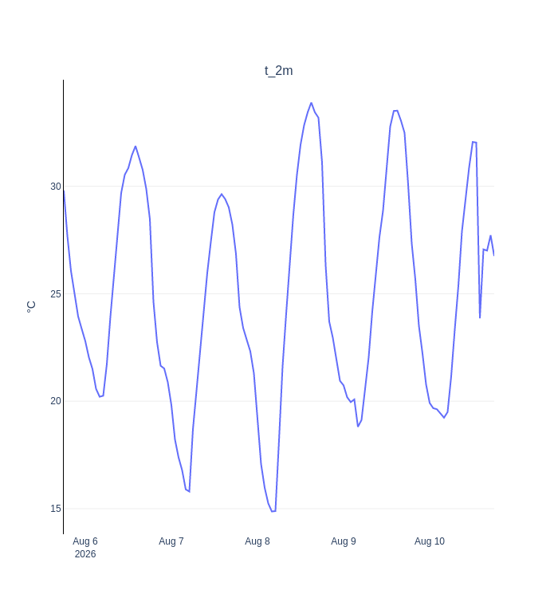

```python
chart.show("png")
```

## Retrieve ensemble data

We can also query the entire ensemble at the same geolocation.

For ICON-CH2-EPS:

```python
req = request.copy()
req['number'] = list(range(1, 21))

ds_ch2 = ekd.from_source(
    "polytope",
    "mchgj",
    req,
    stream=False
).to_xarray()
```

```
2026-08-06 11:18:27 - INFO - Sending request...
{'request': 'class: od\n'
            "date: '20260805'\n"
            "expver: '0001'\n"
            'feature:\n'
            '  axes:\n'
            '  - longitude\n'
            '  - latitude\n'
            '  points:\n'
            '  - - 8.565074\n'
            '    - 47.453928\n'
            '  range:\n'
            '    end: 120\n'
            '    start: 0\n'
            '  time_axis: step\n'
            '  type: timeseries\n'
            'levtype: sfc\n'
            'model: icon-ch2-eps\n'
            'number:\n'
            '- 1\n'
            '- 2\n'
            '- 3\n'
            '- 4\n'
            '- 5\n'
            '- 6\n'
            '- 7\n'
            '- 8\n'
            '- 9\n'
            '- 10\n'
            '- 11\n'
            '- 12\n'
            '- 13\n'
            '- 14\n'
            '- 15\n'
            '- 16\n'
            '- 17\n'
            '- 18\n'
            '- 19\n'
            '- 20\n'
            "param: '500011'\n"
            'stream: enfo\n'
            "time: '1800'\n"
            'timespan: none\n'
            'type: pf\n',
 'verb': 'retrieve'}
2026-08-06 11:18:27 - INFO - Request accepted. Please poll ./d5196551-9f1c-450b-a932-5f75ccfb7b3c for status
2026-08-06 11:18:27 - INFO - Checking request status (d5196551-9f1c-450b-a932-5f75ccfb7b3c)...
2026-08-06 11:18:27 - INFO - The current status of the request is 'queued'
2026-08-06 11:18:28 - INFO - The current status of the request is 'processing'
2026-08-06 11:18:30 - INFO - The current status of the request is 'processed'
```

For ICON-CH1-EPS:

```python
req = request.copy()
req['model'] = 'icon-ch1-eps'
req['number'] = list(range(1, 11))
req['feature'] = {
    "type": "timeseries",
    "points": [zrh_geo_point],
    "time_axis": "step",
    "range": {"start": 0, "end": 33},
    "axes": ["longitude", "latitude"],
}


ds_ch1 = ekd.from_source(
    "polytope",
    "mchgj",
    req,
    stream=False
).to_xarray()
```

```
2026-08-06 11:18:31 - INFO - Sending request...
{'request': 'class: od\n'
            "date: '20260805'\n"
            "expver: '0001'\n"
            'feature:\n'
            '  axes:\n'
            '  - longitude\n'
            '  - latitude\n'
            '  points:\n'
            '  - - 8.565074\n'
            '    - 47.453928\n'
            '  range:\n'
            '    end: 33\n'
            '    start: 0\n'
            '  time_axis: step\n'
            '  type: timeseries\n'
            'levtype: sfc\n'
            'model: icon-ch1-eps\n'
            'number:\n'
            '- 1\n'
            '- 2\n'
            '- 3\n'
            '- 4\n'
            '- 5\n'
            '- 6\n'
            '- 7\n'
            '- 8\n'
            '- 9\n'
            '- 10\n'
            "param: '500011'\n"
            'stream: enfo\n'
            "time: '1800'\n"
            'timespan: none\n'
            'type: pf\n',
 'verb': 'retrieve'}
2026-08-06 11:18:32 - INFO - Request accepted. Please poll ./82f6a0be-e434-498a-b87b-50cf7377f8a4 for status
2026-08-06 11:18:32 - INFO - Checking request status (82f6a0be-e434-498a-b87b-50cf7377f8a4)...
2026-08-06 11:18:32 - INFO - The current status of the request is 'queued'
2026-08-06 11:18:32 - INFO - The current status of the request is 'processing'
2026-08-06 11:18:35 - INFO - The current status of the request is 'processed'
```

We can also request the same data from **IFS** using **ECMWF Polytope**. To access the data follow the instructions on https://polytope.readthedocs.io/en/latest/Service/Installation/ in section Authentication. Once you’ve obtained your credentials, add them to your existing `config.yaml` file, which already contains the MeteoSwiss credentials.

```python
import os

# Use your ECMWF Polytope credentials
os.environ["POLYTOPE_USER_KEY"] = config["ecmwf"]["key"]
os.environ["POLYTOPE_USER_EMAIL"] = config["ecmwf"]["user_email"]
os.environ["POLYTOPE_ADDRESS"] = "polytope.ecmwf.int"
```

```python
request = {
    "class": "od",
    "stream": "enfo",
    "type": "pf",
    "date": date,
    "time": time,
    "levtype": "sfc",
    "expver": "0001",
    "domain": "g",
    "param": "167",
    "number": "1/to/50",
    "step": "0/to/160",
    "feature": {
        "type": "timeseries",
        "points": [[round(c, 2) for c in zrh_geo_point]],
        "time_axis": "step",
        "axes": ["longitude", "latitude"]
    }
}

ds_ifs = ekd.from_source(
    "polytope",
    "ecmwf-mars",
    request,
    stream=False
)
```

```
2026-08-06 11:18:36 - INFO - Sending request...
{'request': 'class: od\n'
            "date: '20260805'\n"
            'domain: g\n'
            "expver: '0001'\n"
            'feature:\n'
            '  axes:\n'
            '  - longitude\n'
            '  - latitude\n'
            '  points:\n'
            '  - - 8.57\n'
            '    - 47.45\n'
            '  time_axis: step\n'
            '  type: timeseries\n'
            'levtype: sfc\n'
            'number: 1/to/50\n'
            "param: '167'\n"
            'step: 0/to/160\n'
            'stream: enfo\n'
            "time: '1800'\n"
            'type: pf\n',
 'verb': 'retrieve'}
2026-08-06 11:18:36 - INFO - Request accepted. Please poll ./33b40e20-bd97-42eb-920c-3cf83294d45c for status
2026-08-06 11:18:36 - INFO - Checking request status (33b40e20-bd97-42eb-920c-3cf83294d45c)...
2026-08-06 11:18:37 - INFO - The current status of the request is 'queued'
2026-08-06 11:18:37 - INFO - The current status of the request is 'processing'
2026-08-06 11:18:43 - INFO - The current status of the request is 'processed'
```

## Plotting ensemble members of time series

```python
from earthkit.plots.interactive import Chart

TIME_FREQUENCY = "1h"
QUANTILES = [0, 0.1, 0.25, 0.5, 0.75, 0.9, 1]

chart = Chart()

# CH1
chart.box(ds_ch1, quantiles=QUANTILES, line_color="#ea5545")
chart.line(ds_ch1, aggregation="mean", line_color="grey",
           time_frequency=TIME_FREQUENCY,
           name="ICON-CH1-EPS (mean)")

# CH2
chart.box(ds_ch2, quantiles=QUANTILES, line_color="#ef9b20")
chart.line(ds_ch2, aggregation="mean", line_color="grey",
           time_frequency=TIME_FREQUENCY,
           name="ICON-CH2-EPS (mean)")

# IFS
chart.box(ds_ifs, quantiles=QUANTILES, line_color="#27aeef")
chart.line(ds_ifs, aggregation="mean", line_color="grey",
           time_frequency=TIME_FREQUENCY,
           name="IFS (mean)")
```

If you're viewing this on GitHub, plots are static and we export them as PNGs using `chart.show("png")`.

If you're running the notebook locally, use `chart.show()` to enable interactivity.

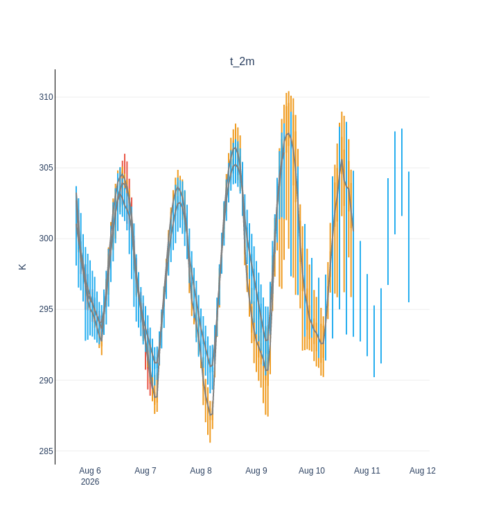

```python
chart.show("png")
```